# econ2200Ch03 slides

[figure not shown]

## ECON2200H

### Introduction to Statistics for Economics and Management

### 2020 Winter Term

### Week 02: Describing Data, II

#### 13 January 2020

## Outline

- Descriptive statistics (for quantitative data). Measuring
  - central tendency
  - dispersion
  - asymmetry of distribution
  - position

## 1. Measures of central tendency

- Measures of central tendency, or central location, are often referred to as averages.
- The purpose of a measure of location is to pinpoint the centre of a set of data.
- An average is a measure of location that shows the central value of the data.
  - Example, the average number of hours high-school students spend playing video games each week.
- Five measures of tendency
  - the arithmetic mean
  - the weighted mean
  - the median
  - the mode
  - the geometric mean
- Each measure can be applied to both a population and a sample

### 1-1. Arithmetic mean

#### Population mean

- Let $X$ be the variable of interest, e.g., the height of a high-school student in Canada in 2020.
- Let $x_j$ be the value of $X$ for the $j$-th observation in population.
- Let $N$ be the size of population, e.g., all high-school students in Canada in 2020.
- Define $\mu$ the population arithmetic mean, e.g., the average height of high-school students in Canada in 2020.
- Then $\mu = \frac{\sum_{j=1}^N x_j}{N} = \frac{1}{N}(x_1+x_2+x_3+...+x_{N-1}+x_N)$.

#### Example. NHL goals scored

- Fourteen teams in the Eastern Conference of the NHL. Table shows the number of goals scored by each team in the 2013–2014 season.

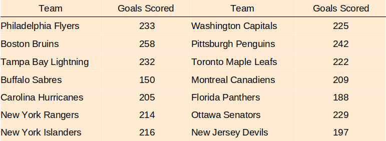

- Variable of interest, $X$, is the number of goals scored by a team in 2013/2014 season.
- Observed values of $X$, $x_j$ is the number of goals scored by team $j$.
- Population is all NHL teams in east conference, population size $N=14$.
- The arithmetic mean is $\mu = \frac{\sum_{j=1}^{14} x_j}{14} = 215.71$.

#### Sample mean

- Sample mean is defined similarly, $\overline{x} = \frac{\sum_{i=1}^n x_i}{n}$, where $n$ is the sample size.
- Example: Sample is 14 internet users and their reported numbers of minutes on social networks.
- The arithmetic mean for this sample is $\overline{x} = \frac{1}{14}(85+93+105+87+120+97+120+79+114+107+115+88+109+113) = 102.3$.

### 1-2. Median

- **Median** is the midpoint of the values in a set of numbers ordered from the minimum to the maximum.
- If the data sample size is odd, median is the value separating the higher half and the lower half of the sample.
- If the data sample size is even, median is the average of two values in the middle.

### Example

- Age of seven employees in a bank: 31, 35, 29, 30, 32, 33,34.
- Order the values of the sample: 29, 30, 31, 32, 33, 34, 35.
- Median age for the sample is 32.
- Let's add another employee whose age is 35.
- Median age of the sample of size 8 is (32+33)/2 = 32.5.

### 1-3. Mode

- **Mode** is the value of the variable of interest that occurs with the most frequency.
- In the above example, for the sample with size 8, the mode is 35.

#### Relative positions of mean, median, and mode.

[output not shown]

Negatively skewed distribution

[figure not shown]

### 1-4. Weighted mean in a sample

- **Weighted mean** is the average of observed values in a sample where each observation has a weight, and the weight is applied to taking the average.
- Let $X$ be the variable of interest, $x_i$ be the observed value of $X$ for the $i$-th observation, $w_i$ is the weight of the $i$-th observation, and $n$ be the sample size.
- Weighted mean is $\overline{x}_w = \frac{w_1 x_1+ w_2 x_w + ... + w_n x_n}{w_1+w_2+...+w_n}$, or $$\overline{x}_w = \frac{\sum_{i=1}^n w_i x_i}{\sum_{i=1}^n w_i}.$$

#### Example

- Grade of quiz in a class.

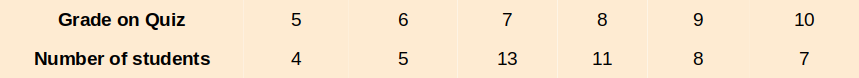

- Sample size (number of observations) is $n=6$, population is $N = 48=(4+5+13+11+8+7)$.
- Weighted mean is $\overline{x}_w = \frac{4\cdot 5 +5 \cdot 6 +13 \cdot 7 +11\cdot 8+8 \cdot 9 +7\cdot 10}{4+5+13+11+8+7} = 7.73$.
- Arithmetic mean (for the sample of size 6) is $\overline{x} = \frac{5+6+7+8+9+10}{6} = 7.5$.

### 1-5. Geometric mean

- Let $X$ be the variable of interest, $x_j$ be the value of $X$ for the observation $j$, in a population of size $N$.
- The **geometric mean** of $X$ is defined as $$\mu_G = (x_1 \cdot x_2\cdot \dots \cdot x_N)^{\frac{1}{N}}.$$
- We can also write it as $\mu_G = \left(\prod_{j=1}^N x_j\right)^{\frac{1}{N}}$.
- Similarly, the geometric mean for a sample of size $n$ is $\overline{x}_G = \left(\prod_{i=1}^n x_i\right)^{\frac{1}{n}}$.
- Geometric mean is more useful than arithmetic mean for measuring the average changes of percentages, ratios, indexes. It is also used for measuring average growth rates over time.
- (Optional) For your information. If $x_i>0$ for all $i$, then $\overline{x}_G \le \overline{x}$, geometric mean is smaller than arithmetic mean; They equal if $x_i=x>0$ for all $i$.
- Example. Rate of return on investment in firm ABC for 5 successive years was: 20%, 30%, -30%, 50%, 300%.
- The geometric mean rate of gross return is $\overline{x}_G = (1.2\cdot 1.3 \cdot 0.7 \cdot 1.5 \cdot 4.0)^{1/5}=1.4564$, the rate of net return is 45.64% per year.
- Arithmetic mean rate of gross return is $\overline{x} =\frac{1}{5}(1.2+ 1.3 + 0.7 + 1.5 + 4.0) = 1.74$.
- Another use of geometric mean is to measure average growth rates. Let $x_1$ be the value of $X$ in year 1, $x_T$ be the value of $X$ in year $T$.
- The average yearly growth rate over the $T$ years is $\left(\frac{x_T}{x_1} \right)^{\frac{1}{T-1}} -1$.
- To see why, write $\mu_G = \left(\frac{x_2}{x_1}\cdot \frac{x_3}{x_2}\cdot \frac{x_3}{x_2}\cdot \cdots\cdot \frac{x_T}{x_{T-1}}\right)^{\frac{1}{T-1}} = \left(\frac{x_T}{x_{1}}\right)^{\frac{1}{T-1}}$.
- Example: See econ2200Ch03Examples.ipynb

## 2. Measures of Dispersion

- **Dispersion** of a variable of interest tells how far it is between the low and high values.
- It is of significant interest and importance, for example, dispersion in labor income, gender gaps in education and income, etc.
- Many measures, we study
  - Range
  - Mean deviation
  - Variance; standard deviation
  - Coefficient of variation
- Notation: $X$ is the variable of interest, $x_i$ or $x_j$ is the value of $X$ for observation $i$ or $j$, $n$ is the sample size, $N$ is the population size.

### 2-1. Range and Mean deviation

- Range is the maximum value minus the minimum value in a sample or population
- Mean deviation (MD) of $X$ in a sample is defined as $\frac{\sum_{i=1}^n | x_i- \overline{x}|} {n}$.
- Example: MD = 110/6 = 18.33

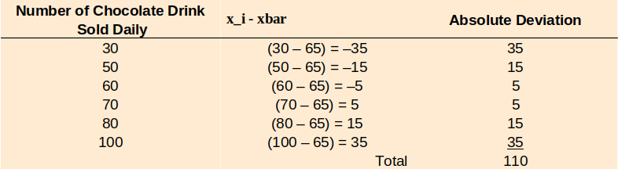

### 2-2. Variance and standard deviation

- Variance and standard deviation are both slightly different between population and sample.
- Population variance is $\sigma^2 = \frac{\sum_{j=1}^N (x_j - \mu)^2}{N}$, where $\mu$ is the population arithmetic mean.
- Population standard deviation is the square root of population variance, $\sigma = \sqrt{\frac{\sum_{j=1}^N (x_j - \mu)^2}{N}}$.
- Terms $x_j - \mu$ are called residuals, deviation from the mean.
- Sample variance is $s^2 = \frac{\sum_{i=1}^n (x_i - \overline{x})^2}{n-1}$, where $\overline{x}$ is the sample arithmetic mean.
- Sample standard deviation is the square root of population variance, $s = \sqrt{\frac{\sum_{i=1}^n (x_i - \overline{x})^2}{n-1}}$.
- Different from $\sigma^2$ and $\sigma$, here we use $n-1$ instead of $n$ in the denominator.
- FYI: Using $n-1$ instead of $n$ is called the Bessel's correction, it corrects the bias of estimating population variance $\sigma^2$ by using $s^2 = \frac{\sum_{i=1}^n (x_i - \overline{x})^2}{n}$. Why the bias? There are $n$ independent observations in the sample, but there are only $n - 1$ independent residuals, because $\sum_{i=1}^n(x_i -\overline{x}) = 0$.
- Sample variance can also be written as $s^2 = \frac{(\sum_{i=1}^n x_i^2) - \frac{1}{n}(\sum_{i=1}^n x)^2}{n-1}$.

**Example**: prices of Jelly

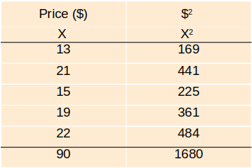

- Sample variance is $s^2 = \frac{1680 - 90 \cdot 90 / 5}{5-1}=15\$^2$.

### Chebyshev's inequality

- In math, for a random variable $X$ with mean value $\mu$ and variance $\sigma^2$, for any number $k>0$, $$\text{Prob}(|X -\mu|\ge k \sigma) \le \frac{1}{k^2}.$$
- Statistically and roughly, in words, the proportion of the values that lie within $k$ standard deviations of the mean is at least $1-1/k^2$, where $k>1$.
- For a symmetrical bell-shaped frequency distribution:
  - Approximately 68% of observations lie within $\pm 1$ standard deviation of the mean.
  - About 95% of observations lie within $\pm 2$ standard deviations of the mean.
  - About 99.7% lie within $\pm 3$ standard deviations of the mean.
- A symmetrical bell-shaped curve showing the relationship between the standard deviation and the observations

[figure not shown]

### 2-3. Coefficient of variation

- Variances and standard deviations have units (e.g., dollars, meters), making them difficult to compare among different variables.
- We want to normalize the dispersion measure, by dividing them by the mean.
- The **coefficient of variation** is the ratio of the standard deviation over the arithmetic mean, expressed as a percentage, $CV = \frac{s}{\overline{x}}$.
- Coefficient of variation allows us to make a meaningful comparison of different standard deviations.

## 3. Skewness

- Skewness measures the degree of asymmetry of the distribution of observed values.
- A set of values is **skewed to the right** or **positively skewed** if there is a single peak and the values extend much further to the right of the peak than to the left of the peak.
  - In this case the mean is larger than the median.
- In a **negatively skewed distribution** there is a single peak but the observations extend further to the left, in the negative direction, than to the right.
  - The mean is smaller than the median.
- Shapes of Frequency Polygons

[figure not shown]

### Pearson's Coefficient of Skewness

- Pearson's coefficient of skewness is $sk = \frac{3(\text{mean}-\text{median})}{\text{standard deviation}}$.
- Another measure of skewness is $sk = \frac{n}{(n-1)(n-2)}\left[\sum_{i=1}^n \left(\frac{x_i - \overline{x}}{s}\right)^3\right]$.

**Example**. Earnings per share, in dollars, for a sample of 16 stocks in some year.

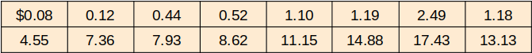

- Mean is 5.76, standard deviation is 5.85. Median is 3.52.
- Pearson's coefficient of skewness is $\frac{3(5.76 - 3.52)}{5.85}=1.15$. Distribution displays a positive skewness.

## 4. Relative positions

- The standard deviation is the most widely used measure of dispersion.
- There are other ways of describing the variation or spread in a set of data.
- One method is to determine the **location of values** that divide a set of observations into equal parts,
  - they include **quartiles**, **deciles**, and **percentiles**.
- Quartiles divide a set of observations into four equal parts.
- Deciles divide a set of observations into ten equal parts.
- Percentiles divide a set of observations into 100 equal parts.
- For a number of observations, $n$, the location of the $P$th percentile is $$L_p = (n+1)\frac{P}{100}.$$

**Example**

- Commissions earned by a sample of 17 real estate agents in a particular month.

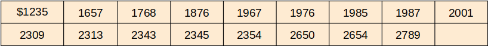

## 5. Box plots

- A **box plot** is a graph based on quartiles, that helps to picture a set of data
- Five statistics of data are needed to construct a box plot:
  - Minimum value
  - First quartile
  - Median
  - Third quartile
  - Maximum value

**Example**. Time to deliver pizza, in minutes. Samples size is 20.

[figure not shown]

- $x_{min} = 15, x_{max} = 31$, median = 18, time at the 1st quartile $Q_1=16$, $Q_2 = 26$.

**Example**. Given the box plot, find statistics.

[figure not shown]

- $x_{min} =$
- $x_{max} =$
- median =
- $Q_1=$
- $Q_2 = $

## 6. Descriptive statistics for grouped data

- Recall, some data are grouped, with frequency for each group. For example
- For example, list prices of real estate in Edmonton

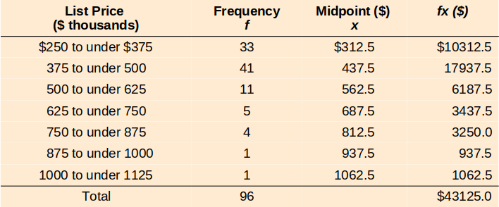

- In the example, each class is an interval of prices. We need to use the midpoints.
- The **arithmetic mean of grouped data** is defined as $\overline{x} = \frac{\sum_{i=1}^n f_i x_i}{n}$,
  - where $f_i$ is the frequency falling into class $i$, $x_i$ is the midpoint value of class $i$, $n$ is sample size.
- In the above example, $\overline{x} = \frac{43125}{96} = \$449.2 \ \text{thousand}$.
- This resembles but differs from the weighted arithmetic mean for continuous data.
- **Median of grouped data** for population data is based on the median class, i.e., the class that the middle observation falls into.
- It is defined as $\text{Median} = L + \frac{N/2 - f^c}{f} \cdot i$. Strange notation.
- Here, $L$ is the lower limit (boundary) of the median class
- $N$ is the population size (number of observations)
- $f$ is the frequency of the median class
- $f^c$ is the cumulative frequency up to but excluding the median class
- $i$ is the class width of the median class
- For sample data, replace $N$ with sample size $n$.

**Example 1**. Marks of a quiz in a course with 30 students.

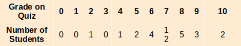

[figure not shown]

- Order the data.
- The position of the median mark $L_{50} = (30+1)\frac{50}{100} = 15.5$, so the median class is 7.
- In the median class, the mark is 7, so the median mark is 7.
- No need to apply to the above formula, since it does not have an interval.

**Example 2**. List prices on an area of a city.

[figure not shown]

- Order observations.

[figure not shown]

- Find the position of the median price, $L_p = (n+1)\frac{P}{100} = (98+1)\frac{50}{100} = 49.5$.
- Median class is "400 to under 800".
- Median price is in the class where the 49.5th observation falls into.
- Median price then equal $L + \frac{n/2 - f^c}{f} \cdot i = 400 + \frac{98/2-40}{42} \cdot 400 = 485.7$.
- **Standard deviation of grouped data** is defined as $$s = \sqrt{\frac{(\sum_{i=1}^n f_i x_i^2) - \frac{(\sum_{i=1}^n f_ix_i)^2}{n}}{n-1}}.$$
- Here, $f_i$ is the frequency of class $i$, $x_i$ is the midpoint value of class $i$, $n$ is the sample size (total number of frequencies).

**Example**. List price of real estates in an area of city ABC.

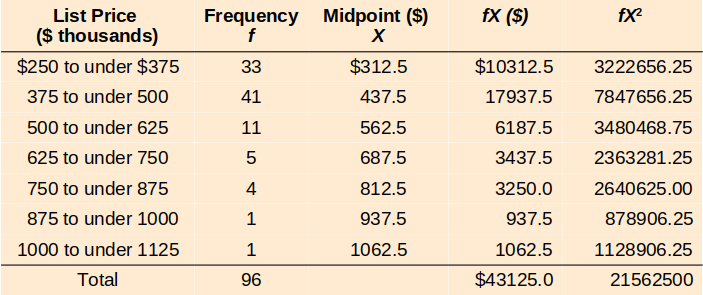

- Apply the formula, we have $s = \sqrt{\frac{21562500 - \frac{43125^2}{96}}{96-1}} = 151.83$.

## 7. Summary

- Lots of formulas, refer to the end of chapter summary in textbook.

```python
from IPython.display import HTML
HTML('''<script>
  function code_toggle() {
    if (code_shown){
      $('div.input').hide('500');
      $('#toggleButton').val('Show Code')
    } else {
      $('div.input').show('500');
      $('#toggleButton').val('Hide Code')
    }
    code_shown = !code_shown
  }

  $( document ).ready(function(){
    code_shown=false;
    $('div.input').hide()
  });
</script>
<form action="javascript:code_toggle()"><input type="submit" id="toggleButton" value="Show Code"></form>''')
```